# Environmental Plastic Waste Analysis

Author

Shravani Subramanian

```r
library(tidyverse)
library(dplyr)
library(httr)
library(tidyjson)
library(jsonlite)
library(glue)
library(purrr)
library(countrycode)
library(forstringr)
library(scales)
library(hexbin)
library(broom)
library(gt)
```

## Context

The Environmental Plastic Waste Data comes from the **“Break Free from Plastic”** movement and covers information on plastic use across the world, organized by country, type of plastic, source of plastic, and year (2019 or 2020). The data comes from brand audits and cleanups conducted by volunteers. Some limitations of this dataset are that the countries will not have an equal sampling effort and the data depends on volunteer participation. Additionally, the amount of collected waste does not necessarily tell us how much plastic there is in general. Aside from those, the data is useful to help identify major corporate contributors to plastic pollution in our environment. It can also help inform environmental policy workers and provide corporate accountability.

## Data Cleaning

It seems as though initially the 2019 and 2020 datasets were imported separately from directories. Only the csv files were chosen from those respective directories. We then read the two CSV files with specified column types to prevent any confusion. The code then combines multiple files into a single file for each year (one for 2019 and one for 2020) through `map_dfr`. Next, the code cleans column names for both files using the `janitor::clean_names()` command, and makes the names consistent across years. A year column is also added to the datasets.

Individual Changes:

2020:

- The `Grand_Total` variable is converted from character to numeric.

2019:

- The country names are extracted from file names & stored in a `country` column.
- Combines duplicate columns `pp_2` and `pp` as well as `ps` & `ps_2`.
- Handles missing values using `is.na` and an `ifelse()` statement.
- Drops `ps_2` & `pp_2`

Lastly, the 2019 and 2020 datasets are merged using `bind_rows()`and exported to a csv file.

## Research Questions

Using Current Data:

1. Have certain plastic types (e.g. Polystyrene or High density polyethylene) become more or less common over time?

Using Supplemental Data:

1. How does annual mean temperature affect total plastic count?
2. Do countries with higher GDPs have more plastic counting events, and thus a higher total plastic count?

# Checkpoint 3

## Temperature Data Set (Additional Country-Level Data)

```r
# Read in Temperature data set
temp <- read.csv("combined_temperature.csv")

temp <- temp |>
  filter(Year %in% (c(2019, 2020)),) |>
  rename(AnnualMeanTemp = Annual.Mean)

# Show first 10 rows of temp data set
head(temp, 10)
```

```
              Country Year AnnualMeanTemp X5.yr.smooth Code
1  Dominican Republic 2019          24.91        24.90  DOM
2  Dominican Republic 2020          24.91        24.81  DOM
3       United States 2019           9.73        10.12  USA
4       United States 2020          10.02        10.00  USA
5              Zambia 2019          22.40        22.21  ZMB
6              Zambia 2020          22.03        22.13  ZMB
7             Vanuatu 2019          24.37        24.54  VUT
8             Vanuatu 2020          24.73        24.61  VUT
9               Tonga 2019          25.18        25.20  TON
10              Tonga 2020          25.40        25.19  TON
```

The temperature data set includes data on the mean annual temperatures for all countries worldwide for the years 1901-2022, but we are particularly interested in the years 2019 and 2020. The 3-letter ISO code for each country is also included. We chose this data set because we wanted to explore how climate affects plastic degradation and consumption across different countries around the world.

## GDP Data Set (Additional Country-Level Data)

```r
get_gdp <- function(country, key = my_key) {
  safe_parse <- safely(
    function(country, key) {

      response <- GET(
        url = "https://api.api-ninjas.com/v1/gdp",
        query = list(country = country),
        add_headers("X-Api-Key" = key)
      )

      data <- content(response, as = "text", encoding = "UTF-8")
      fromJSON(data)
    }
  )

  out <- safe_parse(country, key)

  # if there was an error, return empty data frame
  if (!is.null(out$error)) {
    return(data.frame())
  }

  # if result is empty, return empty data frame
  if (length(out$result) == 0) {
    return(data.frame())
  }

  # force result into data frame
  as.data.frame(out$result) |> filter(year %in% c(2019, 2020))
}

# Test Case
# can call function with 2-letter ISO code (get_gdp("CA")) or with full country name:
get_gdp("Canada")
```

```r
gdp <- map_dfr(unique(temp$Code), get_gdp)
head(gdp, 10)
```

```r
write_csv(x = gdp, file = "stat431-gdp.csv")
```

```r
gdp <- read_csv("stat431-gdp.csv")
gdp
```

```
# A tibble: 325 × 8
   country  year gdp_growth gdp_nominal gdp_per_capita_nominal   gdp_ppp
   <chr>   <dbl>      <dbl>       <dbl>                  <dbl>     <dbl>
 1 DOM      2019        5.1      89.0                    8595.   215.
 2 DOM      2020       -6.7      78.9                    7554.   210.
 3 USA      2019        2.6   21540.                    65561. 21540.
 4 USA      2020       -2.2   21354.                    64462. 21354.
 5 ZMB      2019        1.4      23.3                    1268.    62.2
 6 ZMB      2020       -2.8      18.1                     958.    60.2
 7 VUT      2019        3.2       0.93                   3187.     0.84
 8 VUT      2020       -5         1.01                   3341.     0.809
 9 TON      2019       -0.2       0.445                  4435.     0.621
10 TON      2020        1.3       0.445                  4439.     0.638
# ℹ 315 more rows
# ℹ 2 more variables: gdp_per_capita_ppp <dbl>, gdp_ppp_share <dbl>
```

## “Meta” Dataset: Combining Temperature, GDP, and Plastic Waste Data Sets

```r
# Keep gdp_per_capita_nominal variable
gdp_per_capita <- gdp |>
  select(country, year, gdp_nominal, gdp_per_capita_nominal)

# Remove X5.yr.smooth variable from temperature data, join with gdp data set
combined_temp_gdp <- temp |>
  select(-X5.yr.smooth) |>
  left_join(gdp_per_capita, by = c("Code" = "country", "Year" = "year"))
```

```r
plastics <- readr::read_csv('https://raw.githubusercontent.com/rfordatascience/tidytuesday/main/data/2021/2021-01-26/plastics.csv')
# Sum up plastic and grand total plastic counts for each country, for each year
plastics_sum <- plastics |>
  group_by(country, year) |>
  summarize(
    across(empty:grand_total,\(x) sum(x, na.rm = TRUE)),
    num_events = first(num_events),
    volunteers = first(volunteers),
    .groups = "drop"
  )
head(plastics_sum, 10)
```

```
# A tibble: 10 × 13
   country     year empty  hdpe  ldpe     o   pet    pp    ps   pvc grand_total
   <chr>      <dbl> <dbl> <dbl> <dbl> <dbl> <dbl> <dbl> <dbl> <dbl>       <dbl>
 1 Argentina   2019     0   430   110  1214  2752   562   232    36        5336
 2 Argentina   2020   128   132   141   212   144   263    62     4        1086
 3 Armenia     2020     0     0     0     0     8     0     0     0           8
 4 Australia   2019     0     0     0     0     6     0     0     0           6
 5 Australia   2020     4    33   222   898   141   361     3     6        1668
 6 Bangladesh  2019     0     0     0    32     0     0     0     0          32
 7 Bangladesh  2020     0   376     2  1559   299    89    58     0        2383
 8 Benin       2019     0     0     0     0  9976     0     0     0        9976
 9 Benin       2020     0     0     0     0   342     0     0     0         342
10 Bhutan      2019     0     0     0     0  7000     0     0     0        7000
# ℹ 2 more variables: num_events <dbl>, volunteers <dbl>
```

```r
# Create country code variable for plastics data
plastics_sum <- plastics_sum |>
  filter(!(country == "EMPTY")) |>
  mutate(Code = countrycode(sourcevar = country, origin = "country.name", destination = "iso3c")) |>
  rename(Year = year, Country = country)

head(plastics_sum, 10)
```

```
# A tibble: 10 × 14
   Country     Year empty  hdpe  ldpe     o   pet    pp    ps   pvc grand_total
   <chr>      <dbl> <dbl> <dbl> <dbl> <dbl> <dbl> <dbl> <dbl> <dbl>       <dbl>
 1 Argentina   2019     0   430   110  1214  2752   562   232    36        5336
 2 Argentina   2020   128   132   141   212   144   263    62     4        1086
 3 Armenia     2020     0     0     0     0     8     0     0     0           8
 4 Australia   2019     0     0     0     0     6     0     0     0           6
 5 Australia   2020     4    33   222   898   141   361     3     6        1668
 6 Bangladesh  2019     0     0     0    32     0     0     0     0          32
 7 Bangladesh  2020     0   376     2  1559   299    89    58     0        2383
 8 Benin       2019     0     0     0     0  9976     0     0     0        9976
 9 Benin       2020     0     0     0     0   342     0     0     0         342
10 Bhutan      2019     0     0     0     0  7000     0     0     0        7000
# ℹ 3 more variables: num_events <dbl>, volunteers <dbl>, Code <chr>
```

```r
# Combine plastics data with temp/GDP
meta_data <- inner_join(plastics_sum, combined_temp_gdp, by = c("Code", "Year")) |>
  select(-Country.y) |>
  rename(Country = Country.x)
```

### How does annual mean temperature affect total plastic count?

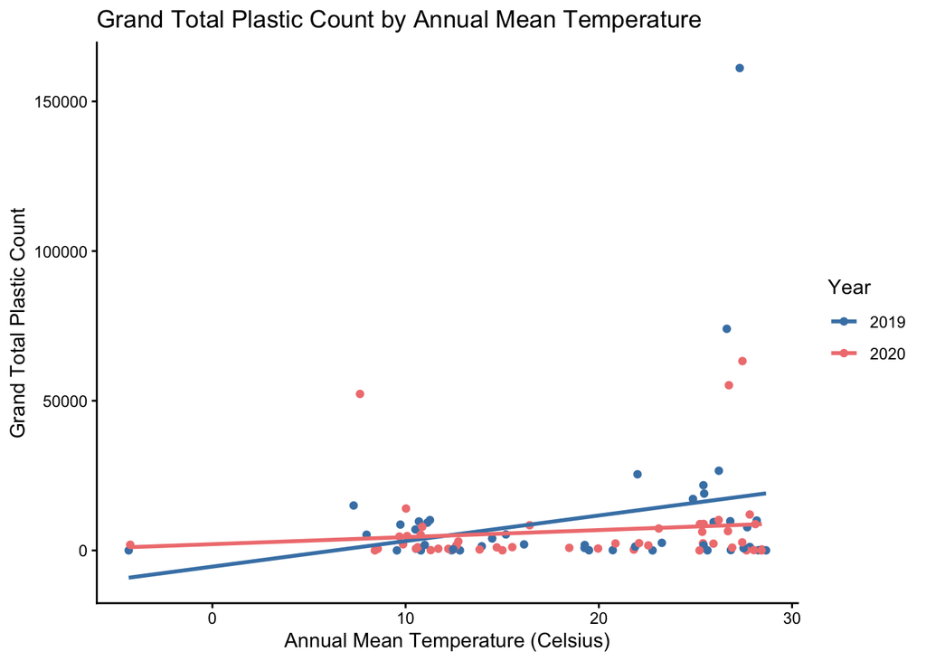

```r
# Grand Total Plastic Count by Annual Mean Temperature
ggplot(data = meta_data, aes(x = AnnualMeanTemp, y = grand_total, color = factor(Year))) +
  geom_point() +
  geom_smooth(method = "lm", se = FALSE) +
  labs(x = "Annual Mean Temperature (Celsius)",
       y = "Grand Total Plastic Count",
       title = "Grand Total Plastic Count by Annual Mean Temperature",
       color = "Year") +
  scale_color_manual(values = c("2019" = "steelblue", "2020" = "lightcoral")) +
  theme_classic()
```

### Do countries with higher GDPs have more plastic counting events, and thus a higher total plastic count?

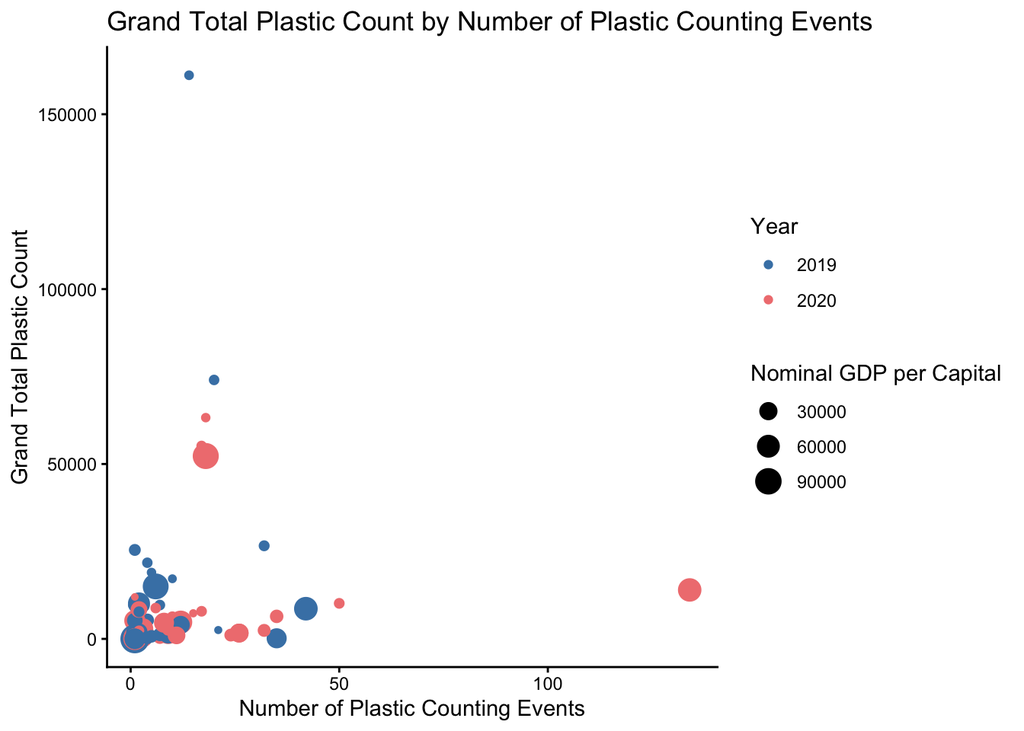

```r
# Grand Total Plastic Count by Number of Plastic Counting Events
ggplot(data = meta_data, aes(x = num_events, y = grand_total, color = factor(Year))) +
  geom_point(aes(size = gdp_per_capita_nominal)) +
  labs(x = "Number of Plastic Counting Events",
       y = "Grand Total Plastic Count",
       title = "Grand Total Plastic Count by Number of Plastic Counting Events",
       color = "Year",
       size = "Nominal GDP per Capital") +
  scale_color_manual(values = c("2019" = "steelblue", "2020" = "lightcoral")) +
  theme_classic()
```

```r
write_csv(x=meta_data, file = "stat431-meta.csv")
```

# Checkpoint 4

```r
plastic_temp_gdp <- read_csv("stat431-meta.csv")
```

```r
plastic_temp_gdp <- plastic_temp_gdp |>
  mutate(continent = countrycode(Country,
                                  origin = "country.name",
                                  destination = "continent"))
```

## RQ #1: How does change in GDP relate to change in the total amount of plastic collected?

```r
changed <- plastic_temp_gdp |>
  group_by(Country, continent, Year) |>
  summarise(grand_total = sum(grand_total, na.rm = TRUE), .groups = "drop") |>
  pivot_wider(names_from = Year, values_from = grand_total) |>
  rename(
    total_2019 = `2019`,
    total_2020 = `2020`
  ) |>
  mutate(change = total_2020 - total_2019) |>
  drop_na(change, continent)
```

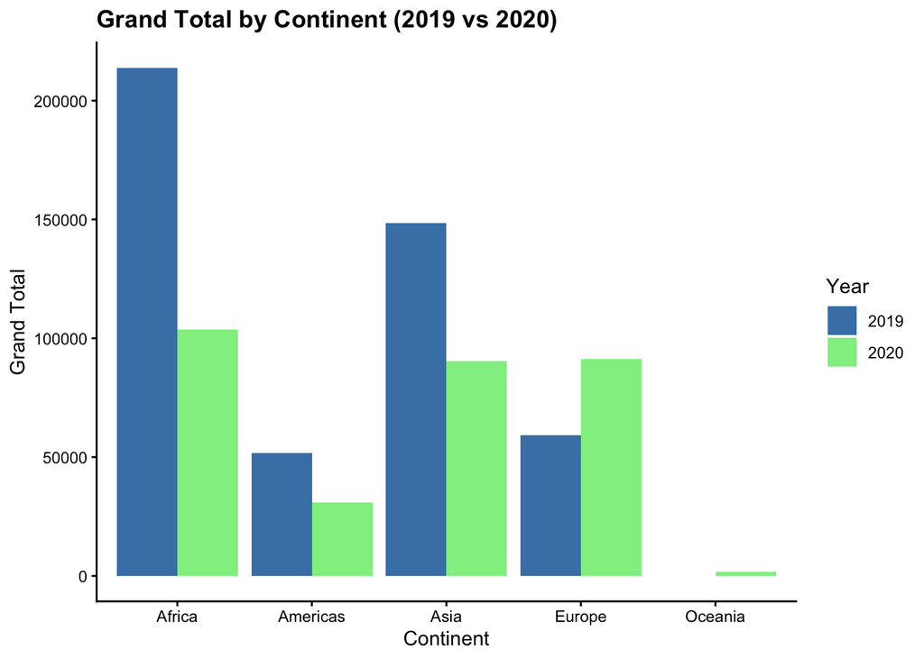

Figure 1.1. Barplot for Change in Grand Total Plastic from 2019-2020, by Continent

```r
continent_year <- plastic_temp_gdp |>
  group_by(continent, Year) |>
  summarise(grand_total = sum(grand_total, na.rm = TRUE), .groups = "drop")

ggplot(continent_year, aes(x = continent, y = grand_total, fill = factor(Year))) +
  geom_col(position = "dodge") +
  labs(
    title = "Grand Total by Continent (2019 vs 2020)",
    x = "Continent",
    y = "Grand Total",
    fill = "Year"
  ) +
  scale_fill_manual(values = c("steelblue", "lightgreen")) +
  theme_classic() +
  theme(plot.title = element_text(face = "bold"))
```

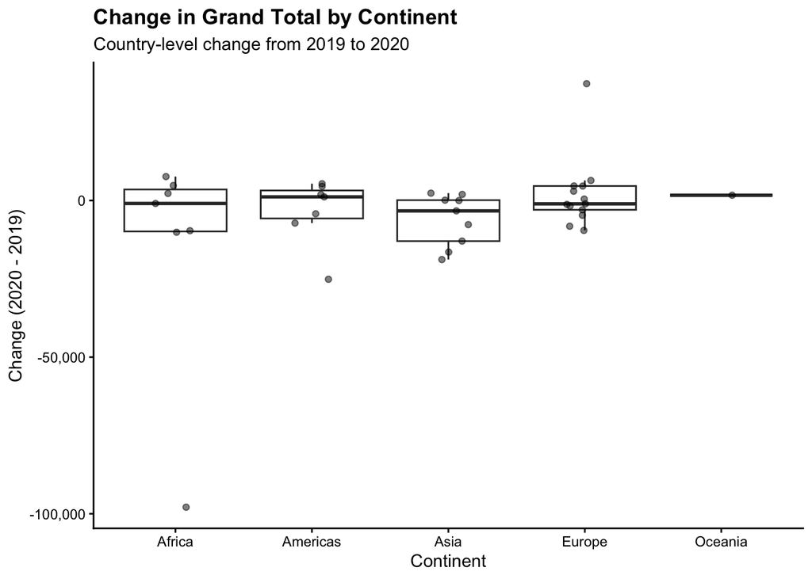

Figure 1.2. Boxplot for Change in Grand Total Plastic from 2019-2020, by Continent

```r
ggplot(changed, aes(x = continent, y = change)) +
  geom_boxplot(outlier.shape = NA) +
  geom_jitter(width = 0.15, alpha = 0.5) +
  scale_y_continuous(labels = comma) +
  labs(
    title = "Change in Grand Total by Continent",
    subtitle = "Country-level change from 2019 to 2020",
    x = "Continent",
    y = "Change (2020 - 2019)"
  ) +
  theme_classic() +
  theme(plot.title = element_text(face = "bold"))
```

We noticed an outlier in Africa that was that was heavily compressing the scale of the boxplot. We identified the outlier to be Nigeria.

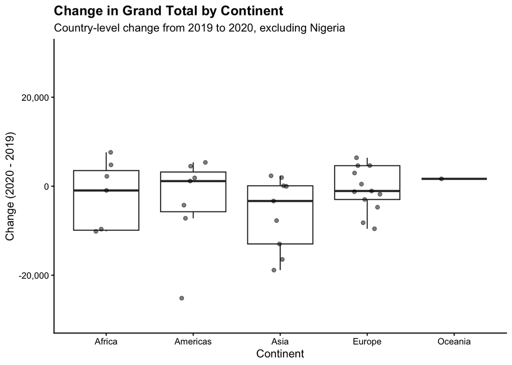

Figure 1.3. Boxplot for Change in Grand Total Plastic from 2019-2020, by Continent (excluding Africa outlier, Nigeria)

```r
ggplot(changed, aes(x = continent, y = change)) +
  geom_boxplot(outlier.shape = NA) +
  geom_jitter(width = 0.15, alpha = 0.5) +
  coord_cartesian(ylim = c(-30000, 30000))+
  scale_y_continuous(labels = comma) +
  labs(
    title = "Change in Grand Total by Continent",
    subtitle = "Country-level change from 2019 to 2020, excluding Nigeria",
    x = "Continent",
    y = "Change (2020 - 2019)"
  ) +
  theme_classic() +
  theme(plot.title = element_text(face = "bold"))
```

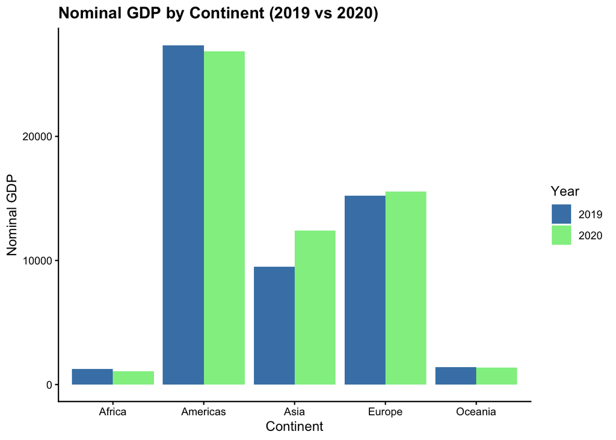

Figure 1.4. Barplot for Change in GDP from 2019-2020, by Continent

```r
continent_year <- plastic_temp_gdp |>
  group_by(continent, Year) |>
  summarise(gdp_nominal = sum(gdp_nominal, na.rm = TRUE), .groups = "drop")

ggplot(continent_year, aes(x = continent, y = gdp_nominal, fill = factor(Year))) +
  geom_col(position = "dodge") +
  labs(
    title = "Nominal GDP by Continent (2019 vs 2020)",
    x = "Continent",
    y = "Nominal GDP",
    fill = "Year"
  ) +
  scale_fill_manual(values = c("steelblue", "lightgreen")) +
  theme_classic() +
  theme(plot.title = element_text(face = "bold"))
```

```r
# Calculating Percent Change in GDP from 2019 to 2020
gdp_changed <- plastic_temp_gdp %>%
  arrange(Country, Year) %>%
  group_by(Country) %>%
  mutate(gdp_pct_change = (gdp_nominal / lag(gdp_nominal) - 1) * 100)
```

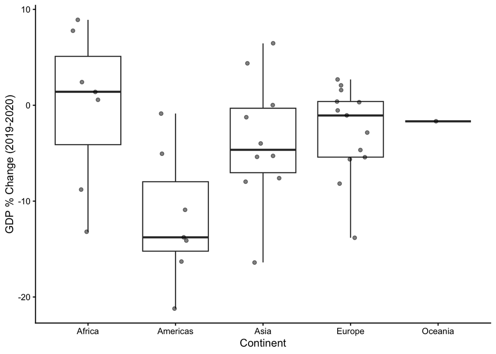

```r
ggplot(gdp_changed, aes(x = continent, y = gdp_pct_change)) +
  geom_boxplot() +
  geom_jitter(width = 0.2, alpha = 0.5) +
  labs(y = "GDP % Change (2019-2020)", x = "Continent") +
  theme_classic() +
  theme(plot.title = element_text(face = "bold"))
```

## RQ #2: Is there a relationship between a country’s mean annual temperature and the total amount of plastic collected?

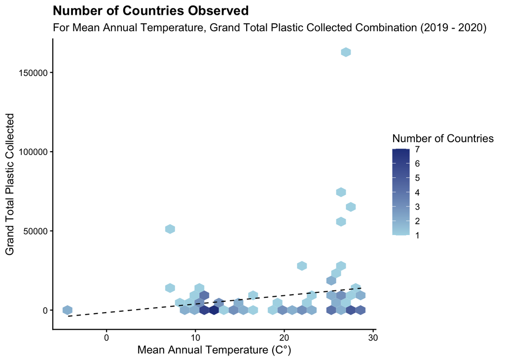

```r
ggplot(data = plastic_temp_gdp) +
  geom_hex(mapping = aes(x = AnnualMeanTemp, y = grand_total)) +
  scale_fill_gradient(low = "lightblue", high = "royalblue4") +
  geom_smooth(aes(x = AnnualMeanTemp, y = grand_total),
              method = "lm", se = FALSE,
              color = "black", linewidth = 0.5, lty = 2) +
  labs(x = "Mean Annual Temperature (C°)",
       y = "Grand Total Plastic Collected",
       fill = "Number of Countries",
       title = "Number of Countries Observed",
       subtitle = "For Mean Annual Temperature, Grand Total Plastic Collected Combination (2019 - 2020)") +
  theme_classic() +
  theme(plot.title = element_text(face = "bold"))
```

```r
# Fitting a linear model
plastic.fit <- lm(grand_total~AnnualMeanTemp, data = plastic_temp_gdp)
summary(plastic.fit)
```

```
Call:
lm(formula = grand_total ~ AnnualMeanTemp, data = plastic_temp_gdp)

Residuals:
   Min     1Q Median     3Q    Max
-13809  -8193  -4250    943 148036

Coefficients:
               Estimate Std. Error t value Pr(>|t|)
(Intercept)     -1535.6     5255.7  -0.292   0.7708
AnnualMeanTemp    536.4      262.9   2.040   0.0442 *
---
Signif. codes:  0 '***' 0.001 '**' 0.01 '*' 0.05 '.' 0.1 ' ' 1

Residual standard error: 20100 on 93 degrees of freedom
Multiple R-squared:  0.04284,   Adjusted R-squared:  0.03255
F-statistic: 4.163 on 1 and 93 DF,  p-value: 0.04416
```

Heatmap of Plastic Composition by Continent

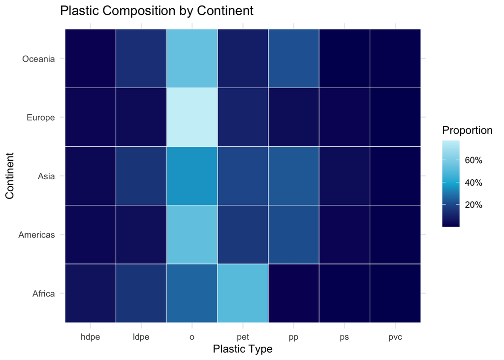

```r
plastic_long <- plastic_temp_gdp %>%
  pivot_longer(
    cols = c(hdpe, ldpe, o, pet, pp, ps, pvc),
    names_to = "plastic_type",
    values_to = "amount"
  )
heatmap_data <- plastic_long %>%
  group_by(continent, plastic_type) %>%
  summarise(total_amount = sum(amount, na.rm = TRUE), .groups = "drop")

heatmap_prop <- heatmap_data %>%
  group_by(continent) %>%
  mutate(prop = total_amount / sum(total_amount))

ggplot(heatmap_prop, aes(x = plastic_type, y = continent, fill = prop)) +
  geom_tile(color = "white") +
  scale_fill_gradientn(colors = c("#03045E","#00B4D8", "#CAF0F8"),
    labels = scales::percent
  ) +
  labs(title = "Plastic Composition by Continent",
       fill = "Proportion",
       x= "Plastic Type",
       y= "Continent") +
  theme_minimal()
```

Stacked Barplot for Plastic Type Composition by Continent

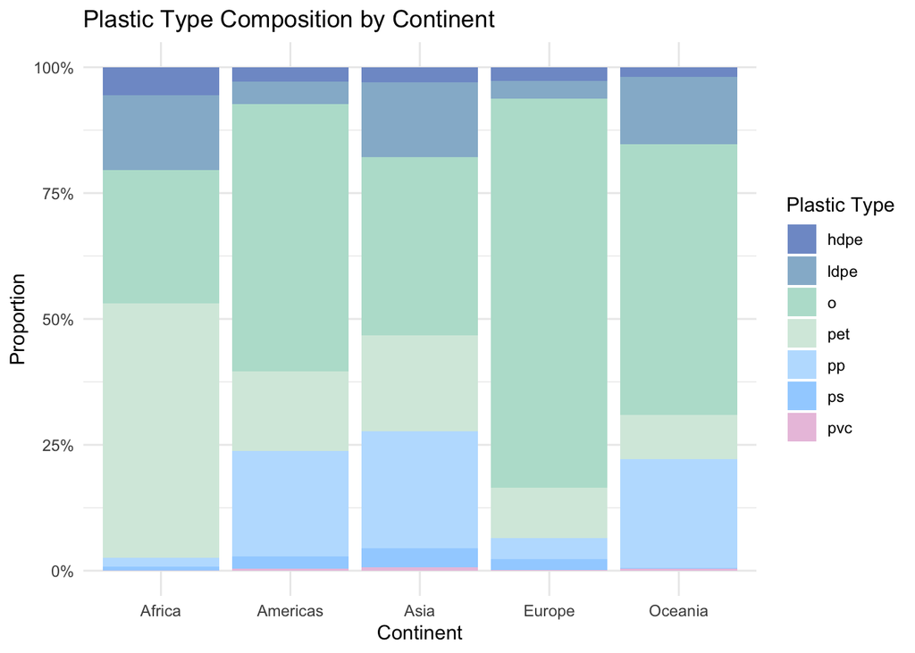

```r
continent_plastic <- plastic_long %>%
  group_by(continent, plastic_type) %>%
  summarise(total_amount = sum(amount, na.rm = TRUE), .groups = "drop")

ggplot(continent_plastic, aes(x = continent, y = total_amount, fill = plastic_type)) +
  geom_col(position = "fill") +
  scale_y_continuous(labels = scales::percent) +
  scale_fill_manual(values = c(
    "hdpe" = "#809bce",
    "ldpe" = "#95b8d1",
    "o"    = "#b8e0d2",
    "pet"  = "#d6eadf",
    "pp"   = "#bde0fe",
    "ps"   = "#a2d2ff",
    "pvc"  = "#eac4df"

  ))+
  labs(
    title = "Plastic Type Composition by Continent",
    x = "Continent",
    y = "Proportion",
    fill = "Plastic Type"
  ) +
  theme_minimal()
```

Scatterplot of Log Grand total and Temperature

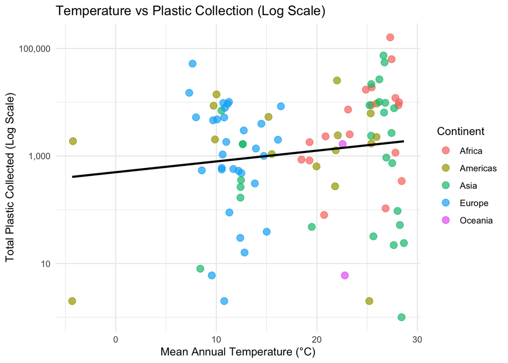

```r
ggplot(plastic_temp_gdp, aes(x = AnnualMeanTemp, y = grand_total, color = continent)) +
  geom_point(alpha = 0.7, size = 3) +
  scale_y_log10(labels = scales::comma) +
  geom_smooth(method = "lm", se = FALSE, color = "black") +
  labs(
    title = "Temperature vs Plastic Collection (Log Scale)",
    x = "Mean Annual Temperature (°C)",
    y = "Total Plastic Collected (Log Scale)",
    color = "Continent"
  ) +
  theme_minimal()
```

```r
rq1_long <- plastic_temp_gdp %>%
  filter(Year %in% c(2019, 2020)) %>%
  pivot_longer(
    cols = c(hdpe, ldpe, o, pet, pp, ps, pvc),
    names_to = "plastic_type",
    values_to = "amount"
  )
rq1_summary <- rq1_long %>%
  group_by(continent, plastic_type) %>%
  summarise(
    total_amount = sum(amount, na.rm = TRUE),
    .groups = "drop"
  )

rq1_prop_by_type <- rq1_summary %>%
  group_by(plastic_type) %>%
  mutate(prop = total_amount / sum(total_amount)) %>%
  ungroup()

rq1_wide_by_type <- rq1_prop_by_type %>%
  select(continent, plastic_type, prop) %>%
  pivot_wider(
    names_from = plastic_type,
    values_from = prop
  )
```

```r
rq1_wide_by_type %>%
  gt() |>
  tab_header(
    title = "Proportion of Each Plastic Type by Continent",
    subtitle = "Totals combined across 2019 and 2020"
  ) |>
  data_color(
    columns = c(hdpe, ldpe, o, pet, pp, ps, pvc),
    fn = col_numeric(
      palette = c("#CAF0F8", "#0077B6"),  # light → dark blue
      domain = c(0, 1)
    )) |>
  tab_style(
    style = cell_text(weight = "bold", color = "black"),
    locations = cells_title(groups = "title")
  ) |>
  fmt_percent(
    columns = c(hdpe, ldpe, o, pet, pp, ps, pvc),
    decimals = 1
  ) |>
  cols_label(
    continent = "Continent",
    hdpe = "HDPE",
    ldpe = "LDPE",
    o = "Other",
    pet = "PET",
    pp = "PP",
    ps = "PS",
    pvc = "PVC"
  )
```

Proportion of Each Plastic Type by Continent

Totals combined across 2019 and 2020

| Continent | HDPE | LDPE | Other | PET | PP | PS | PVC |
| --- | --- | --- | --- | --- | --- | --- | --- |
| Africa | 56.6% | 51.3% | 25.7% | 68.6% | 6.5% | 14.4% | 4.8% |
| Americas | 7.5% | 4.0% | 13.3% | 5.5% | 20.3% | 12.2% | 16.0% |
| Asia | 23.2% | 38.6% | 25.7% | 19.4% | 65.6% | 54.1% | 68.8% |
| Europe | 12.6% | 5.8% | 35.0% | 6.4% | 7.2% | 19.3% | 10.2% |
| Oceania | 0.1% | 0.2% | 0.3% | 0.1% | 0.4% | 0.0% | 0.3% |